# Lab1_latent_var

2024-01-04

# Factor analysis on mental ability score tests

The classic Holzinger and Swineford (1939) dataset consists of mental ability test scores of seventh- and eighth-grade children from two different schools (Pasteur and Grant-White). In the original dataset (available in the MBESS package), there are scores for 26 tests. However, a smaller subset with 9 variables is more widely used in the literature. Perform first an exploratory factor analysis and then a confirmatory factor analysis on this data set

As a good proxy, let’s first see the structure of the dataset: the dataset is contained in the lavaan library

```r
library(lavaan)
data("HolzingerSwineford1939")
head(HolzingerSwineford1939)
```

```
##   id sex ageyr agemo  school grade       x1   x2    x3       x4   x5        x6
## 1  1   1    13     1 Pasteur     7 3.333333 7.75 0.375 2.333333 5.75 1.2857143
## 2  2   2    13     7 Pasteur     7 5.333333 5.25 2.125 1.666667 3.00 1.2857143
## 3  3   2    13     1 Pasteur     7 4.500000 5.25 1.875 1.000000 1.75 0.4285714
## 4  4   1    13     2 Pasteur     7 5.333333 7.75 3.000 2.666667 4.50 2.4285714
## 5  5   2    12     2 Pasteur     7 4.833333 4.75 0.875 2.666667 4.00 2.5714286
## 6  6   2    14     1 Pasteur     7 5.333333 5.00 2.250 1.000000 3.00 0.8571429
##         x7   x8       x9
## 1 3.391304 5.75 6.361111
## 2 3.782609 6.25 7.916667
## 3 3.260870 3.90 4.416667
## 4 3.000000 5.30 4.861111
## 5 3.695652 6.30 5.916667
## 6 4.347826 6.65 7.500000
```

Since we need just the first 9 variables,

```r
data <- HolzingerSwineford1939[,c("x1","x2","x3","x4","x5","x6","x7","x8","x9")]
```

The correlation matrix provides insights into the relationships between variables and can help to assess whether there are underlying latent factors that explain the observed correlations.

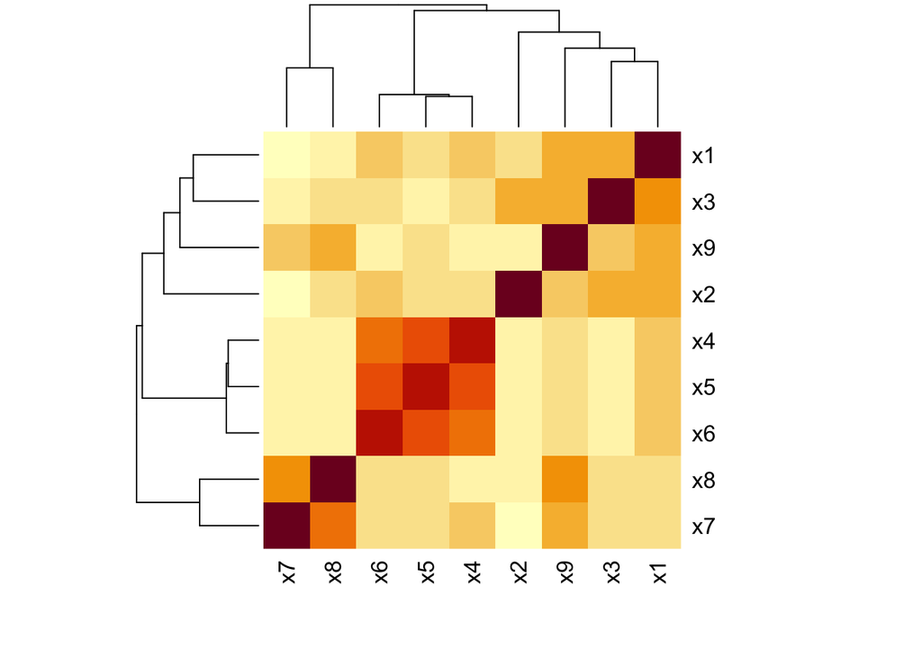

```r
matrcor <- cor(data)
heatmap(matrcor)
```

We can see from the heatmap that could be three latent variables that describes the grouping structure that the correlation matrix present: in particular, we can expect that the latent variables will have different factor loadings for the three group, i.e. $(x_7, x_8)$, $(x_6, x_5, x_4)$ and $(x_1,x_2,x_3,x_9)$.

Now we are going to estimate a factor model respectively with 1,2, and 3 factors using the maximum likelihood method. We will use the factanal function, where we specify the formula

```r
attach(data)
f1<-factanal(~ x1+x2+x3+x4+x5+x6+x7+x8+x9,
              data=data,
             1)
f2<-factanal(~x1+x2+x3+x4+x5+x6+x7+x8+x9,
             data=data,
             2)
f3<-factanal(~x1+x2+x3+x4+x5+x6+x7+x8+x9,
             data=data,
             3)
```

```r
f3
```

```
##
## Call:
## factanal(x = ~x1 + x2 + x3 + x4 + x5 + x6 + x7 + x8 + x9, factors = 3,     data = data)
##
## Uniquenesses:
##    x1    x2    x3    x4    x5    x6    x7    x8    x9
## 0.513 0.749 0.543 0.279 0.243 0.305 0.502 0.469 0.543
##
## Loadings:
##    Factor1 Factor2 Factor3
## x1  0.277   0.623   0.151
## x2  0.105   0.489
## x3          0.663   0.130
## x4  0.827   0.165
## x5  0.861
## x6  0.801   0.212
## x7                  0.696
## x8          0.162   0.709
## x9  0.132   0.406   0.524
##
##                Factor1 Factor2 Factor3
## SS loadings      2.185   1.343   1.327
## Proportion Var   0.243   0.149   0.147
## Cumulative Var   0.243   0.392   0.539
##
## Test of the hypothesis that 3 factors are sufficient.
## The chi square statistic is 22.38 on 12 degrees of freedom.
## The p-value is 0.0335
```

From the model we get some intersting things: most of all we can see the values of the factor loadings. The value that are small are not printed by default by the function, to give emphasis on the most significative ones. We can see that the Factor 1 has high values for the variables $(x_4,x_5,x_6)$: if we see the description of the dataset all of these variables are in somehow related to the sphere of grammar comprehension. Therefore, we can interpret the first latent variable as the variable which captures the linguistic cognitive area. Then, for the second factor we have high values for $(x_1,x_2,x_3,x_9)$ which from the description given in the help is not clear what they actually means, so I don’t know, better to ask a psychologist. In the end, for the third factor we have high values for $(x_7, x_8)$ where those variables can be seen as the speed of capturing what is asked in the question: so, the third latent variables is the one that is related to the sphere of the “speed”.

## Goodness of fit

Now that we fitted three models is time to check which among them is the best one, so, in other words we have to choose the value of $q$, i.e., the number of the latent variabels.

We select the best model using the Chi-square test since for this problem we already find the statistic inside the fitted model. Recall that, under normality assumption, the null hypotesis is $H_0:\Sigma = \Lambda\Lambda' +\Psi$

Inside the factor model just created, there is the significance test under “STATISTIC”, check the ?factanal help.

For the first model

```r
Chisq_f1 <- round(f1$STATISTIC, 3)
Chisq_f1
```

```
## objective
##   306.558
```

And for the other two models

```r
Chisq_f2 <- round(f2$STATISTIC, 3)
Chisq_f3 <- round(f3$STATISTIC, 3)
Chisq_f2
```

```
## objective
##   127.637
```

```r
Chisq_f3
```

```
## objective
##    22.377
```

If we want to compute the degrees of freedom we recall that

$df = \frac{[(p-q)^2-(p+q)]}{2}$

and so, since $p=9$, for the first model the degrees of freddom are $27$.

Luckily, this value is already in the model fitted and it is sufficient to recall it in this way

```r
df_f1 <- f1$dof
df_f1
```

```
## [1] 27
```

And for the other two models

```r
df_f2 <- f2$dof
df_f3 <- f3$dof
```

To get the p-values, again, we just need to look at the fitted model

```r
p_value_df1 <- f1$PVAL
p_value_df2 <- f2$PVAL
p_value_df3 <- f3$PVAL
```

#### Factor Loadings

Now, on the basis of the matrix of the factor loadings, we need to interpret the factors individuated: to extract the loadings we use the “loadings” function which requires an object of class “factanal”. Moreover, since we are interested just on the significant factors we can put a cutoff value inside the function. Although, small loadings are not printed, to draw the eye to the pattern of the larger loadings.

```r
loadings(f1)
```

```
##
## Loadings:
##    Factor1
## x1 0.438
## x2 0.220
## x3 0.223
## x4 0.848
## x5 0.841
## x6 0.838
## x7 0.180
## x8 0.201
## x9 0.307
##
##                Factor1
## SS loadings      2.586
## Proportion Var   0.287
```

```r
loadings(f2)
```

```
##
## Loadings:
##    Factor1 Factor2
## x1 0.324   0.471
## x2 0.151   0.268
## x3         0.455
## x4 0.837   0.158
## x5 0.848   0.127
## x6 0.816   0.181
## x7         0.440
## x8         0.607
## x9 0.126   0.725
##
##                Factor1 Factor2
## SS loadings      2.245   1.664
## Proportion Var   0.249   0.185
## Cumulative Var   0.249   0.434
```

```r
loadings(f3)
```

```
##
## Loadings:
##    Factor1 Factor2 Factor3
## x1  0.277   0.623   0.151
## x2  0.105   0.489
## x3          0.663   0.130
## x4  0.827   0.165
## x5  0.861
## x6  0.801   0.212
## x7                  0.696
## x8          0.162   0.709
## x9  0.132   0.406   0.524
##
##                Factor1 Factor2 Factor3
## SS loadings      2.185   1.343   1.327
## Proportion Var   0.243   0.149   0.147
## Cumulative Var   0.243   0.392   0.539
```

For example, in the f1 model, the variable x4, x5, x6, have high values, suggesting that they strongly contribute to Factor1.

In the f2 model, Variables x1, x2, and x9 show stronger relationships with Factor2. Same for the x8 and x9 in the f3 model. Actually, we already did this interpretation for the model with three factors before, after we fitted the model. Would you say something more?

#### Communalities

And now let’s compute now the communalities: recall that the communalities are defined as $h_i^2 = \sum_{k=1}^{p}\lambda_{ki}^2$

Computing communalities can provide insights into how well the factors account for the observed variability in the data: in particular, high communalities suggest that the factors are capturing a substantial portion of the variance in the observed variables.

So, we just need to sum by rows the squared loadings

```r
comm_f1 <- rowSums(loadings(f1)^2)
comm_f2 <- rowSums(loadings(f2)^2)
comm_f3 <- rowSums(loadings(f3)^2)
```

```r
sum(comm_f1)
```

```
## [1] 2.585581
```

```r
sum(comm_f2)
```

```
## [1] 3.908608
```

```r
sum(comm_f3)
```

```
## [1] 4.854672
```

Adding a latent factor to a model, will increase the communalities, like in the PCA, since the variance explained will be for sure bigger and bigger as we add latent variables to the model: therefore, just to have a proof of this, let’s fit the model with 4 latent factors

```r
f4<-factanal(~x1+x2+x3+x4+x5+x6+x7+x8+x9,
             data=data,
             4)
comm_f4 <- rowSums(loadings(f4)^2)
```

Now, to have also a visual understanding of the communalities, let’s plot them in a bar plot

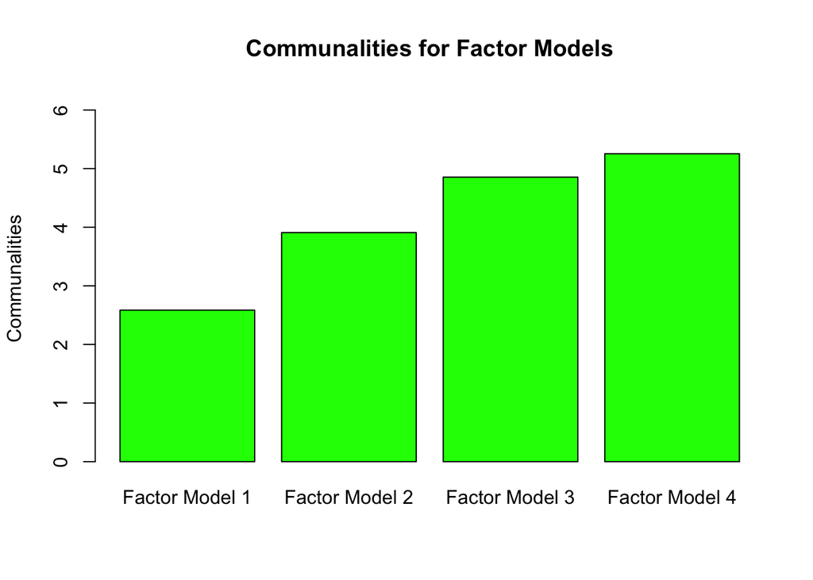

```r
# Create a vector of communalities
communalities <- c(sum(comm_f1), sum(comm_f2), sum(comm_f3), sum(comm_f4))

# Factor model labels
factor_models <- c("Factor Model 1", "Factor Model 2", "Factor Model 3", "Factor Model 4")

# Create a bar plot
barplot(communalities, names.arg = factor_models, col = "green", main = "Communalities for Factor Models", ylab = "Communalities", ylim = c(0, max(communalities) + 1))
```

What we see here is that adding an additional factor increase the communalities, although from the third to the fourth model the increase is not that big as in the previous ones. This can help to estabilish that the model with three factors is the best one.

Now, we want to compute the percentage of the variance of the model explained by each model:

```r
percVar_f1 <- sum(comm_f1)/9
percVar_f2 <- sum(comm_f2)/9
percVar_f3 <- sum(comm_f3)/9

percVar_f1
```

```
## [1] 0.2872868
```

```r
percVar_f2
```

```
## [1] 0.4342898
```

```r
percVar_f3
```

```
## [1] 0.5394079
```

So, what we did in this analysis can be seen in this way: first, check the correlation matrix of the observed variables and see if there is some grouping going on from the values inside the matrix (or the heatmap). Then, fit a latent variable model where the essence is a model for the correlation matrix of $x$, where it’s defined as $\Sigma = \Lambda\Lambda' + \Psi$: now, this lambda matrix is crucial, beacuse it’s the variance of our model with latent variables in some sense (check the posterior distribution of $y|x$ in the slide). To see if our analysis was a good analysis, we can check if the observed matrix (the one computed in the first lines) is similar to the one that we estimated with the fitted model: this last matrix is called “reproduced correlation matrix”.

Here we compute the reproduced correlation matrix which is defined as:

$corr = \lambda_{ij}\lambda_{ij}'$

```r
repcorr_f1 <- loadings(f1)%*%t(loadings(f1))
repcorr_f2 <- loadings(f2)%*%t(loadings(f2))
repcorr_f3 <- loadings(f3)%*%t(loadings(f3))
```

Now, to check the goodness of fit we simply takes the difference of the matrix, and we can do it since they have the same dimensions: what we expect is to have a sparse matrix outside the diagonal, since if the model was well fitted it should give the same $\lambda_{ij}$

Let’s do this for the model with three factors

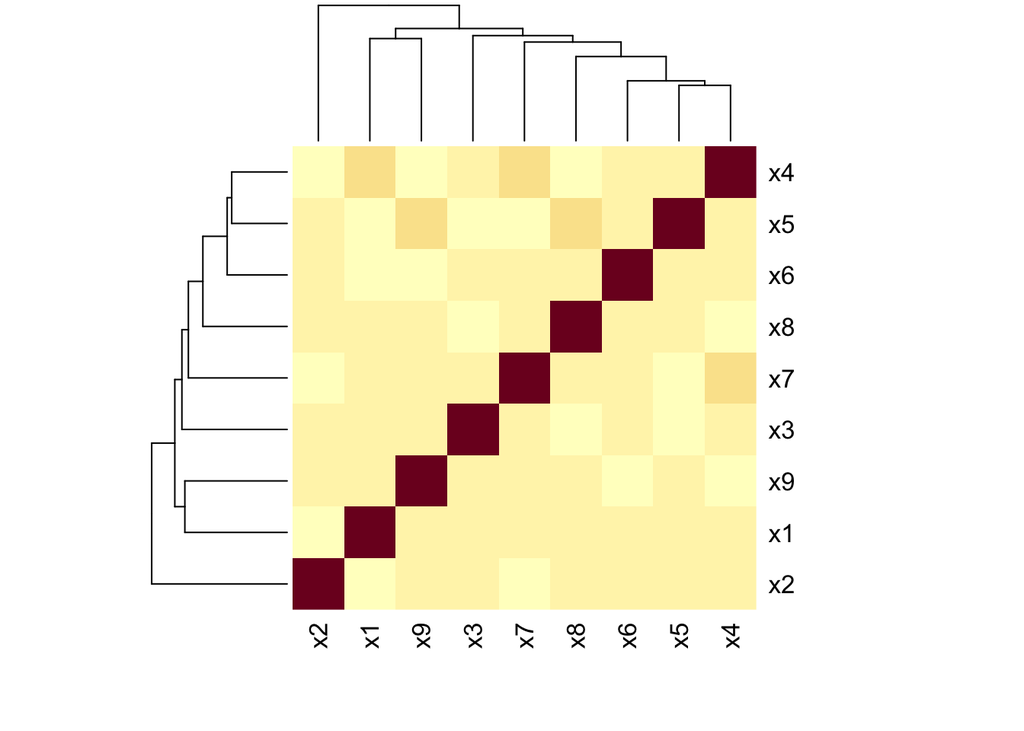

```r
corr_check <- heatmap(matrcor - repcorr_f3)
```

As we can see from the heatmap, outside the main diagonal the values are near zero.